# R Code for Behavioural differences between ornamented and unornamented male Red-backed Fairywrens (*Malurus melanocephalus*) in the nonbreeding season

Trey C. Hendrix

Updated on 11 February 2023

This document contains the R code used to produce the analyses, figures, and supplemental material for the article submitted to *Emu* entitled “Behavioural differences between ornamented and unornamented male Red-backed Fairywrens (*Malurus melanocephalus*) in the nonbreeding season”. The complete list of authors is: Trey C. Hendrix, Facundo Fernandez-Duque, Sarah Toner, Lauren G. Hitt, Robin G. Thady, Megan Massa, Samantha J. Hagler, Margaux Armfield, Nathalie Clarke, Phoebe Honscheid, Sarah Khalil, Carly E. Hawkins, Samantha M. Lantz, Joseph F. Welklin, John P. Swaddle, Michael S. Webster, and Jordan Karubian.

##### Bookmark 6 September 20222

# I should add all the figure and table captions from the manuscript

# Required Packages

```r
library(readr)
library(ggplot2)
library(dplyr)
library(tidyr)
library(purrr)
library(lme4)
library(MuMIn)
library(broom.mixed)
library(lubridate)
library(stringr)
library(knitr)
library(DHARMa)
library(gridExtra)
library(ggpubr)
```

# Data

This manuscript uses two datasets: (1) focal behavioural observations, which is a file named “RBFW3_Anon_Data_210720.csv” and (2) opportunistic behavioural observations, which is a file named “RBFW3_Anon_Opportunistic_Data_230116.csv”

Both datasets have been uploads to Figshare using the following DOI links:

- Focal data: https://doi.org/10.6084/m9.figshare.15088014.
- Opportunistic data: https://doi.org/10.6084/m9.figshare.21790187

They are also available in the fairywren-nonbreeding-behavior GitHub repository in the “Data” folder. The contents of these datasets are detailed in the descriptions on Figshare and in a metadata file in the GitHub repository.

The majority of our analyses focus on the focal observational data, which is simply referred to as “RBFW” in the following code. The opportunistic behavioural data is used for generate supplementary figures and tables and is referred to as “RBFW_sup” in code.

```r
RBFW <- read_csv(file_path_to_focal_data)
glimpse(RBFW)
```

```
## Rows: 369
## Columns: 38
## $ Observation_ID     <chr> "FFD001", "FFD002", "FFD006", "FFD007", "FFD010", "…
## $ Date               <date> 2016-06-24, 2016-06-24, 2016-06-23, 2016-06-23, 20…
## $ Year               <dbl> 2016, 2016, 2016, 2016, 2016, 2016, 2016, 2016, 201…
## $ Day_of_year        <dbl> 176, 176, 175, 175, 176, 176, 178, 180, 175, 173, 1…
## $ Time               <dbl> 925, 1000, 911, 800, 1150, 1237, 1245, 1150, 1023, …
## $ Bird_ID            <chr> "X05", "U07", "Q08", "J02", "X07", "T01", "M04", "U…
## $ Observer           <chr> "FFD", "FFD", "FFD", "FFD", "FFD", "FFD", "FFD", "F…
## $ Sex                <chr> "M", "M", "M", "M", "M", "M", "M", "M", "M", "M", "…
## $ Plumage_score      <dbl> 100, 100, 0, 0, 0, 100, 0, 0, 0, 0, 0, 40, 0, 0, 0,…
## $ Plumage_group      <chr> "BRIGHT", "BRIGHT", "DULL", "DULL", "DULL", "BRIGHT…
## $ Age                <dbl> 4, 4, 2, 3, 2, 3, 2, 2, 2, 2, 1, 3, 3, 2, 2, 2, 5, …
## $ Age_exact          <chr> "exact", "min", "exact", "min", "exact", "exact", "…
## $ Alarm_calling      <dbl> 0, 0, 0, 0, 0, 0, 0, 0, 0, 0, 0, 0, 0, 0, 0, 0, 2, …
```

[output cut: 25 more lines]

```r
RBFW_sup <- read_csv(file_path_to_opp_data)
glimpse(RBFW_sup)
```

```
## Rows: 728
## Columns: 16
## $ Observation_ID          <chr> "OPP001", "OPP002", "OPP003", "OPP004", "OPP00…
## $ Date                    <date> 2015-06-02, 2015-06-03, 2015-06-09, 2015-06-1…
## $ Year                    <dbl> 2015, 2015, 2015, 2015, 2015, 2015, 2015, 2015…
## $ Time                    <chr> "8H 9M 0S", "10H 45M 0S", "7H 15M 0S", "12H 22…
## $ Behavior                <chr> "Allopreening", "Courtship", "Allopreening", "…
## $ Sender_ID               <chr> "JB4", "JD6", "CI5", "IC7", "GD9", "FB6", "HD2…
## $ Sender_plumage_category <chr> "Ornamented", "Ornamented", "Unornamented", "O…
## $ Sender_sex              <chr> "M", "M", "F", "M", "F", "M", "F", "M", "M", "…
## $ Sender_age              <dbl> 3, 3, 5, 3, 3, 1, 1, 2, 2, 2, 3, 4, 1, 2, 4, 5…
## $ Sender_age_exact        <chr> "exact", "min", "exact", "exact", "exact", "ex…
## $ Receiver_ID             <chr> "GG2", "EG1", "ED4", "CH6", "HI9", "AJ6", "HB1…
## $ Receiver_sex            <chr> "M", "F", "M", "F", "F", "F", "M", "F", "M", "…
## $ Receiver_age            <dbl> 5, 3, 4, 2, 1, 3, 1, 1, 1, 3, 2, 5, 5, 2, 4, 4…
## $ Receiver_age_exact      <chr> "min", "exact", "exact", "exact", "min", "min"…
## $ Social_mate             <dbl> 0, 0, 1, 0, 0, 0, 0, NA, 0, 0, 1, 0, 0, 1, 0, …
## $ Prev_breeding_group     <dbl> 0, 0, NA, 0, NA, 0, 0, 0, 0, 0, 1, 1, 1, 0, 0,…
```

# Logistic Mixed-effects Models

In our analysis, we use logistic mixed-effects models with a binomial distribution and logit link to determine which factors (plumage category, age, and day of year) predict whether or not a behaviour of interest (allopreening, chasing, courtship, preening, and vocalizing) was observed during a focal behavioural observation.

The general format of these models (in the notation of the lme4 package) is:

*Behaviour of interest observed (1 or 0) ~ Plumage category + Year + Age + Day of year + (1|Observer) + (1|Bird ID)*

## Preparing Data for Logistic Mixed-Effects Models

First, it is necessary to add binary variables to our dataset for our behaviours of interest:

```r
binaryifier <- function(var){
  ifelse(var > 0, 1, 0)
}

variables_of_interest <- c("Courtship_prop", "Vocalizing_prop",
                           "Allopreening_prop", "Preening_prop",
                           "Chasing_prop")

RBFW_bin <- RBFW %>%
  mutate_at(.vars = variables_of_interest ,
            .funs = binaryifier) %>%
  rename_at(.vars = variables_of_interest ,
            .funs = list(~gsub("prop", "bin", .))) %>%
  select(Observation_ID, contains("bin"))

RBFW <- RBFW %>%
  left_join(RBFW_bin, by = "Observation_ID")
```

All numeric variables (e.g., age and day of year) in models will be standardized as shown below:

```r
standardizer <- function(x){
  y <- (x - mean(x))/sd(x)
  return(y)
}

RBFW <- RBFW %>%
  mutate(Age_st = standardizer(Age),
         Day_of_year_st = standardizer(Day_of_year))
```

The plumage category and year variables are made to be factors. For plumage category, DULL is set to be the reference category:

```r
RBFW <- RBFW %>%
  mutate(Plumage_group = factor(Plumage_group, levels = c("DULL", "MOULT", "BRIGHT")),
         Year = factor(Year))
```

```r
RBFW <- RBFW %>%
  mutate(Plumage_group_combined = ifelse(Plumage_group == "BRIGHT",
                                         "BRIGHT", "DULL + MOULT"),
         Plumage_group_combined = factor(Plumage_group_combined,
                                         levels = c("DULL + MOULT", "BRIGHT")))
```

## Logistic Mixed-effects Models

Here, we create a function to produce the models described above:

```r
# Formatting for graphs
theme_simple <- theme(panel.grid.major = element_blank(),
                      panel.grid.minor = element_blank(),
                      panel.background = element_blank(),
                      axis.line = element_line(colour = "black"),
                      plot.title = element_text(hjust = 0))

class_colors <- c("navajowhite2", "orange2", "firebrick")
rain_color <- "cyan4"

# Fixed Effects
general_fixed_effects <- paste("Plumage_group", "Year",
                               "Age_st", "Day_of_year_st",
                               sep = " + ")
court_fixed_effects <- paste("Plumage_group_combined", "Year",
                             "Age_st", "Day_of_year_st",
                             sep = " + ")

# Modeling Function
logistic_modeler <- function(dv, iv, df = RBFW){

  formula <- paste(dv, "~", iv,
                   "+ (1| Observer) + (1 | Bird_ID)",
                   collapse = " ") %>%
    as.formula()

  model <- glmer(formula, data = df, family = "binomial",
                 control=glmerControl(optimizer="bobyqa",
                                      optCtrl=list(maxfun=2e5)))

  visualization <- model %>%
    tidy() %>%
    filter(effect == "fixed") %>%
    filter(!(term %in% c("(Intercept)",
                         "sd_(Intercept).Bird_ID",
                         "sd_(Intercept).Observer"))) %>%
    mutate(lower = estimate - 1.96*std.error,
           upper = estimate + 1.96*std.error) %>%
    mutate(term = case_when(term == "Plumage_groupMOULT" ~
                              "Plumage group MOULT",
                            term == "Plumage_groupBRIGHT" ~
                              "Plumage group BRIGHT",
                            term == "Year2017" ~
                              "Year 2017",
                            term == "Year2018" ~
                              "Year 2018",
                            term == "Age_st" ~
                              "Age",
                            term == "Day_of_year_st" ~
                              "Day of year",
                            term == "Plumage_group_combinedBRIGHT" ~
                              "Plumage group BRIGHT*"))  %>%
    ggplot(aes(x = estimate, y = term)) +
    geom_point() +
    geom_linerange(aes(xmin = lower, xmax = upper)) +
    theme_bw() +
    theme(plot.title = element_text(hjust = 0.5)) +
    labs(x = "Model Estimate", y = "Fixed Effect") +
    geom_vline(xintercept = 0, lty = 2, color = "red") +
    ggtitle(str_remove(dv, fixed("_bin")))

  results <- list(summary(model), visualization)

  list <- list(model, results)

  return(list)
}
```

Applying this function to our variables of interest, produces the following results:

```r
logistic_modeler("Allopreening_bin", general_fixed_effects)
```

```
## [[1]]
## Generalized linear mixed model fit by maximum likelihood (Laplace
##   Approximation) [glmerMod]
##  Family: binomial  ( logit )
## Formula: Allopreening_bin ~ Plumage_group + Year + Age_st + Day_of_year_st +
##     (1 | Observer) + (1 | Bird_ID)
##    Data: df
##       AIC       BIC    logLik  deviance  df.resid
##  245.7744  280.9716 -113.8872  227.7744       360
## Random effects:
##  Groups   Name        Std.Dev.
##  Bird_ID  (Intercept) 0.9592
##  Observer (Intercept) 0.0000
## Number of obs: 369, groups:  Bird_ID, 116; Observer, 12
## Fixed Effects:
##         (Intercept)   Plumage_groupMOULT  Plumage_groupBRIGHT
##            -3.26471              0.58685              1.12885
##            Year2017             Year2018               Age_st
##             0.25968              0.01959             -0.58101
##      Day_of_year_st
##            -0.37356
## optimizer (bobyqa) convergence code: 0 (OK) ; 0 optimizer warnings; 1 lme4 warnings
##
## [[2]]
## [[2]][[1]]
## Generalized linear mixed model fit by maximum likelihood (Laplace
##   Approximation) [glmerMod]
##  Family: binomial  ( logit )
## Formula: Allopreening_bin ~ Plumage_group + Year + Age_st + Day_of_year_st +
##     (1 | Observer) + (1 | Bird_ID)
##    Data: df
## Control: glmerControl(optimizer = "bobyqa", optCtrl = list(maxfun = 2e+05))
##
##      AIC      BIC   logLik deviance df.resid
##    245.8    281.0   -113.9    227.8      360
##
## Scaled residuals:
##     Min      1Q  Median      3Q     Max
## -0.7425 -0.3236 -0.2365 -0.1665  5.2509
##
```

[output cut: 16 more lines]

```
## Signif. codes:  0 '***' 0.001 '**' 0.01 '*' 0.05 '.' 0.1 ' ' 1
##
## Correlation of Fixed Effects:
##             (Intr) P_MOUL P_BRIG Yr2017 Yr2018 Age_st
## Plmg_gMOULT -0.200
## Plmg_BRIGHT -0.295  0.516
## Year2017    -0.407 -0.410 -0.429
## Year2018    -0.406 -0.222 -0.428  0.650
## Age_st       0.187 -0.347 -0.567  0.457  0.386
## Day_f_yr_st  0.155  0.087 -0.079  0.033  0.204  0.110
## optimizer (bobyqa) convergence code: 0 (OK)
## boundary (singular) fit: see help('isSingular')
##
##
## [[2]][[2]]
```

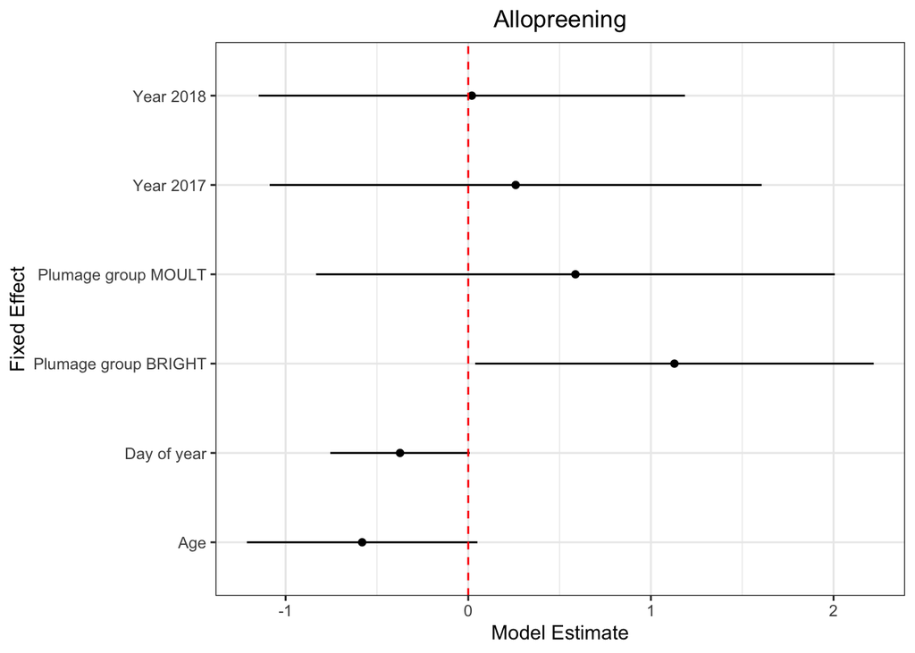

```r
allo_model <- logistic_modeler("Allopreening_bin",
                               general_fixed_effects)[[1]]

logistic_modeler("Courtship_bin", court_fixed_effects)
```

```
## [[1]]
## Generalized linear mixed model fit by maximum likelihood (Laplace
##   Approximation) [glmerMod]
##  Family: binomial  ( logit )
## Formula:
## Courtship_bin ~ Plumage_group_combined + Year + Age_st + Day_of_year_st +
##     (1 | Observer) + (1 | Bird_ID)
##    Data: df
##      AIC      BIC   logLik deviance df.resid
## 125.8506 157.1370 -54.9253 109.8506      361
## Random effects:
##  Groups   Name        Std.Dev.
##  Bird_ID  (Intercept) 0.000
##  Observer (Intercept) 1.483
## Number of obs: 369, groups:  Bird_ID, 116; Observer, 12
## Fixed Effects:
##                  (Intercept)  Plumage_group_combinedBRIGHT
##                      -6.8109                        4.9703
##                     Year2017                      Year2018
##                      -1.1721                       -0.8621
##                       Age_st                Day_of_year_st
##                       0.1633                        0.2507
## optimizer (bobyqa) convergence code: 0 (OK) ; 0 optimizer warnings; 1 lme4 warnings
##
## [[2]]
## [[2]][[1]]
## Generalized linear mixed model fit by maximum likelihood (Laplace
##   Approximation) [glmerMod]
##  Family: binomial  ( logit )
## Formula:
## Courtship_bin ~ Plumage_group_combined + Year + Age_st + Day_of_year_st +
##     (1 | Observer) + (1 | Bird_ID)
##    Data: df
## Control: glmerControl(optimizer = "bobyqa", optCtrl = list(maxfun = 2e+05))
##
##      AIC      BIC   logLik deviance df.resid
##    125.9    157.1    -54.9    109.9      361
##
## Scaled residuals:
##    Min     1Q Median     3Q    Max
```

[output cut: 16 more lines]

```
## ---
## Signif. codes:  0 '***' 0.001 '**' 0.01 '*' 0.05 '.' 0.1 ' ' 1
##
## Correlation of Fixed Effects:
##             (Intr) P__BRI Yr2017 Yr2018 Age_st
## Plm__BRIGHT -0.643
## Year2017    -0.397 -0.057
## Year2018    -0.477 -0.070  0.385
## Age_st      -0.094 -0.192  0.196  0.122
## Day_f_yr_st -0.097  0.013 -0.006  0.172  0.025
## optimizer (bobyqa) convergence code: 0 (OK)
## boundary (singular) fit: see help('isSingular')
##
##
## [[2]][[2]]
```

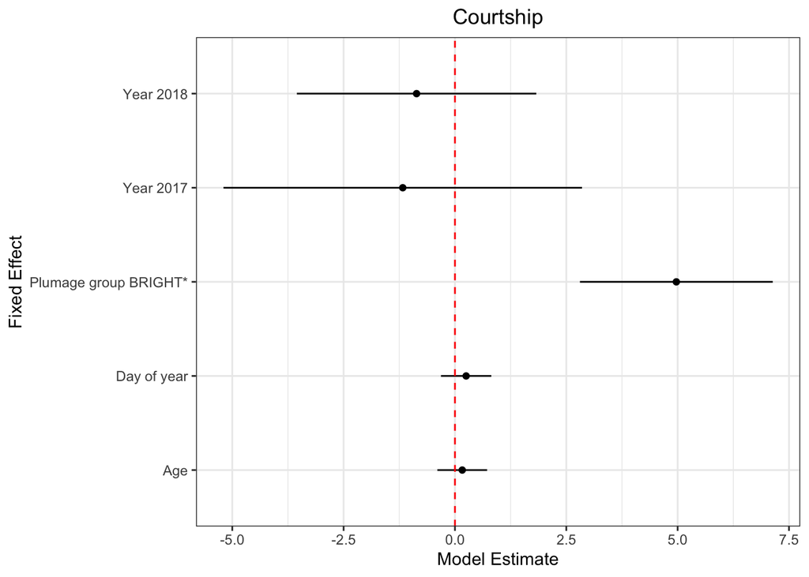

```r
court_model <- logistic_modeler("Courtship_bin",
                                court_fixed_effects)[[1]]

logistic_modeler("Chasing_bin", general_fixed_effects)
```

```
## [[1]]
## Generalized linear mixed model fit by maximum likelihood (Laplace
##   Approximation) [glmerMod]
##  Family: binomial  ( logit )
## Formula: Chasing_bin ~ Plumage_group + Year + Age_st + Day_of_year_st +
##     (1 | Observer) + (1 | Bird_ID)
##    Data: df
##      AIC      BIC   logLik deviance df.resid
## 178.7901 213.9873 -80.3951 160.7901      360
## Random effects:
##  Groups   Name        Std.Dev.
##  Bird_ID  (Intercept) 5.1428
##  Observer (Intercept) 0.5471
## Number of obs: 369, groups:  Bird_ID, 116; Observer, 12
## Fixed Effects:
##         (Intercept)   Plumage_groupMOULT  Plumage_groupBRIGHT
##             -8.6719               0.1195              -0.7026
##            Year2017             Year2018               Age_st
##              4.3083               2.7561               1.2816
##      Day_of_year_st
##              0.6626
##
## [[2]]
## [[2]][[1]]
## Generalized linear mixed model fit by maximum likelihood (Laplace
##   Approximation) [glmerMod]
##  Family: binomial  ( logit )
## Formula: Chasing_bin ~ Plumage_group + Year + Age_st + Day_of_year_st +
##     (1 | Observer) + (1 | Bird_ID)
##    Data: df
## Control: glmerControl(optimizer = "bobyqa", optCtrl = list(maxfun = 2e+05))
##
##      AIC      BIC   logLik deviance df.resid
##    178.8    214.0    -80.4    160.8      360
##
## Scaled residuals:
##     Min      1Q  Median      3Q     Max
## -2.1259 -0.0632 -0.0313 -0.0143  5.4500
##
## Random effects:
```

[output cut: 12 more lines]

```
## Age_st                1.2816     0.7099   1.805  0.07103 .
## Day_of_year_st        0.6626     0.4355   1.521  0.12817
## ---
## Signif. codes:  0 '***' 0.001 '**' 0.01 '*' 0.05 '.' 0.1 ' ' 1
##
## Correlation of Fixed Effects:
##             (Intr) P_MOUL P_BRIG Yr2017 Yr2018 Age_st
## Plmg_gMOULT  0.277
## Plmg_BRIGHT  0.490  0.624
## Year2017    -0.706 -0.443 -0.664
## Year2018    -0.616 -0.342 -0.586  0.743
## Age_st      -0.484 -0.386 -0.653  0.608  0.388
## Day_f_yr_st -0.581 -0.230 -0.488  0.536  0.500  0.433
##
## [[2]][[2]]
```

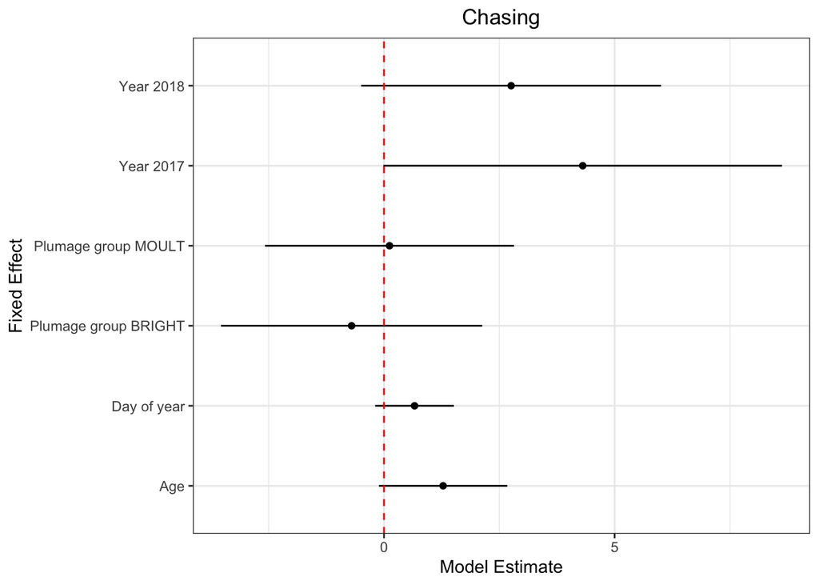

```r
chase_model <- logistic_modeler("Chasing_bin",
                                general_fixed_effects)[[1]]

logistic_modeler("Preening_bin", general_fixed_effects)
```

```
## [[1]]
## Generalized linear mixed model fit by maximum likelihood (Laplace
##   Approximation) [glmerMod]
##  Family: binomial  ( logit )
## Formula: Preening_bin ~ Plumage_group + Year + Age_st + Day_of_year_st +
##     (1 | Observer) + (1 | Bird_ID)
##    Data: df
##       AIC       BIC    logLik  deviance  df.resid
##  502.9680  538.1652 -242.4840  484.9680       360
## Random effects:
##  Groups   Name        Std.Dev.
##  Bird_ID  (Intercept) 0.1420
##  Observer (Intercept) 0.3451
## Number of obs: 369, groups:  Bird_ID, 116; Observer, 12
## Fixed Effects:
##         (Intercept)   Plumage_groupMOULT  Plumage_groupBRIGHT
##            -0.45826              0.84203              0.50909
##            Year2017             Year2018               Age_st
##             0.84211              0.30300             -0.02386
##      Day_of_year_st
##            -0.09409
##
## [[2]]
## [[2]][[1]]
## Generalized linear mixed model fit by maximum likelihood (Laplace
##   Approximation) [glmerMod]
##  Family: binomial  ( logit )
## Formula: Preening_bin ~ Plumage_group + Year + Age_st + Day_of_year_st +
##     (1 | Observer) + (1 | Bird_ID)
##    Data: df
## Control: glmerControl(optimizer = "bobyqa", optCtrl = list(maxfun = 2e+05))
##
##      AIC      BIC   logLik deviance df.resid
##    503.0    538.2   -242.5    485.0      360
##
## Scaled residuals:
##     Min      1Q  Median      3Q     Max
## -1.9276 -0.8566  0.5135  0.8816  1.4540
##
## Random effects:
```

[output cut: 12 more lines]

```
## Age_st              -0.02386    0.14279  -0.167   0.8673
## Day_of_year_st      -0.09409    0.12051  -0.781   0.4349
## ---
## Signif. codes:  0 '***' 0.001 '**' 0.01 '*' 0.05 '.' 0.1 ' ' 1
##
## Correlation of Fixed Effects:
##             (Intr) P_MOUL P_BRIG Yr2017 Yr2018 Age_st
## Plmg_gMOULT -0.136
## Plmg_BRIGHT -0.163  0.439
## Year2017    -0.439 -0.289 -0.347
## Year2018    -0.618 -0.174 -0.354  0.491
## Age_st      -0.032 -0.339 -0.572  0.370  0.326
## Day_f_yr_st -0.143  0.017 -0.032  0.095  0.238  0.037
##
## [[2]][[2]]
```

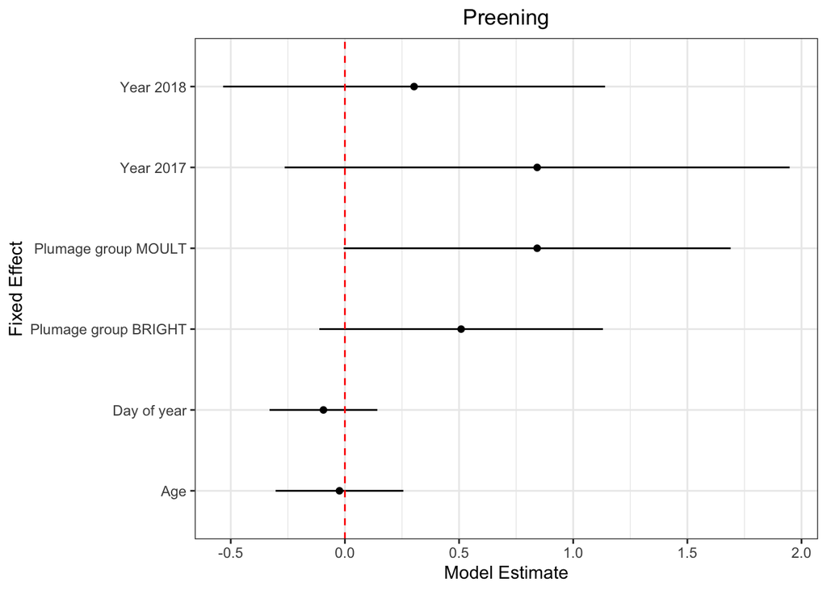

```r
preen_model <- logistic_modeler("Preening_bin",
                                general_fixed_effects)[[1]]

logistic_modeler("Vocalizing_bin", general_fixed_effects)
```

```
## [[1]]
## Generalized linear mixed model fit by maximum likelihood (Laplace
##   Approximation) [glmerMod]
##  Family: binomial  ( logit )
## Formula: Vocalizing_bin ~ Plumage_group + Year + Age_st + Day_of_year_st +
##     (1 | Observer) + (1 | Bird_ID)
##    Data: df
##       AIC       BIC    logLik  deviance  df.resid
##  514.4123  549.6095 -248.2062  496.4123       360
## Random effects:
##  Groups   Name        Std.Dev.
##  Bird_ID  (Intercept) 0.5415
##  Observer (Intercept) 0.0000
## Number of obs: 369, groups:  Bird_ID, 116; Observer, 12
## Fixed Effects:
##         (Intercept)   Plumage_groupMOULT  Plumage_groupBRIGHT
##            0.268543            -0.422781            -0.627202
##            Year2017             Year2018               Age_st
##            0.799328             0.195405             0.164559
##      Day_of_year_st
##           -0.003065
## optimizer (bobyqa) convergence code: 0 (OK) ; 0 optimizer warnings; 1 lme4 warnings
##
## [[2]]
## [[2]][[1]]
## Generalized linear mixed model fit by maximum likelihood (Laplace
##   Approximation) [glmerMod]
##  Family: binomial  ( logit )
## Formula: Vocalizing_bin ~ Plumage_group + Year + Age_st + Day_of_year_st +
##     (1 | Observer) + (1 | Bird_ID)
##    Data: df
## Control: glmerControl(optimizer = "bobyqa", optCtrl = list(maxfun = 2e+05))
##
##      AIC      BIC   logLik deviance df.resid
##    514.4    549.6   -248.2    496.4      360
##
## Scaled residuals:
##     Min      1Q  Median      3Q     Max
## -1.6946 -0.9816  0.6319  0.8446  1.4536
##
```

[output cut: 16 more lines]

```
## Signif. codes:  0 '***' 0.001 '**' 0.01 '*' 0.05 '.' 0.1 ' ' 1
##
## Correlation of Fixed Effects:
##             (Intr) P_MOUL P_BRIG Yr2017 Yr2018 Age_st
## Plmg_gMOULT -0.249
## Plmg_BRIGHT -0.291  0.452
## Year2017    -0.320 -0.399 -0.459
## Year2018    -0.440 -0.202 -0.452  0.536
## Age_st       0.025 -0.310 -0.552  0.480  0.372
## Day_f_yr_st -0.137  0.032 -0.070  0.111  0.265  0.049
## optimizer (bobyqa) convergence code: 0 (OK)
## boundary (singular) fit: see help('isSingular')
##
##
## [[2]][[2]]
```

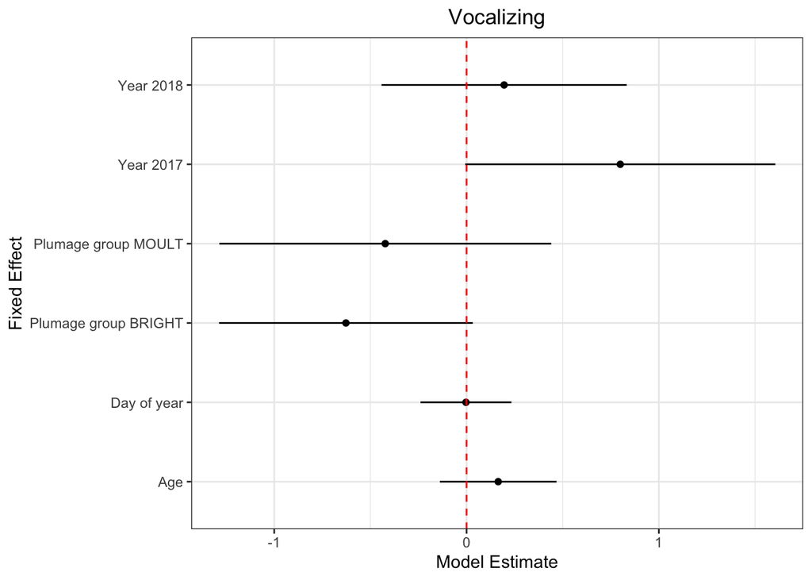

```r
voc_model <- logistic_modeler("Vocalizing_bin",
                              general_fixed_effects)[[1]]
```

## Table 1

```r
null_model_comparer <- function(model, dv, df = RBFW){

  # Null model
  null_formula <- paste(dv, "~", "1 + (1| Observer) + (1 | Bird_ID)",
                        collapse = " ") %>%
    as.formula()

  null_model <- glmer(null_formula, data = df, family = "binomial",
                      control = glmerControl(optimizer="bobyqa",
                                             optCtrl=list(maxfun=2e5)))
  null_loglik <- logLik(null_model)

  # Making dataframe
  model_output <- AICc(model)
  model_df <- tibble(Response_variable = dv,
                     Formula = "Plumage_group + Year + Age_st + Day_of_year_st",
                     AICc = model_output,
                     Pseudo_R2 = as.numeric(1 - logLik(model)/null_loglik))

  # ANOVA
  anova_df <- anova(model, null_model) %>%
    tidy() %>%
    filter(term == "model") %>%
    select(statistic, df, p.value)

  final_df <- model_df %>% bind_cols(anova_df)


  return(final_df)
}


# List of models
models <- list(allo_model, chase_model,
               court_model, preen_model,
               voc_model)


# List of response variables
variables_of_interest_bin <- list("Allopreening_bin", "Chasing_bin",
                                  "Courtship_bin", "Preening_bin",
                                  "Vocalizing_bin")


anova_models <- map2(models, variables_of_interest_bin,
                     null_model_comparer) %>%
  bind_rows() %>%
  select(Response_variable, Formula,
         everything())


table_1 <- anova_models %>%
  select(Response_variable, statistic,
         df, p.value,
         Pseudo_R2) %>%
  mutate(statistic = round(statistic, 3),
         Pseudo_R2 = round(Pseudo_R2, 3),
         p.value = round(p.value, 3))

table_1 %>%
  kable()
```

| Response_variable | statistic | df | p.value | Pseudo_R2 |
| --- | --- | --- | --- | --- |
| Allopreening_bin | 13.233 | 6 | 0.039 | 0.055 |
| Chasing_bin | 10.887 | 6 | 0.092 | 0.063 |
| Courtship_bin | 49.922 | 5 | 0.000 | 0.312 |
| Preening_bin | 9.888 | 6 | 0.129 | 0.020 |
| Vocalizing_bin | 5.451 | 6 | 0.487 | 0.011 |

## Figure 1

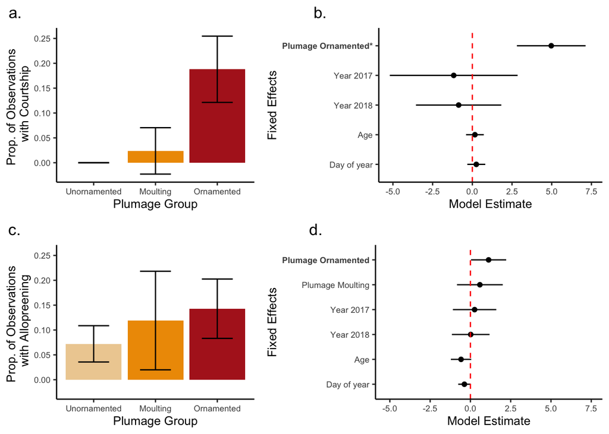

```r
std_error <- function(x){

  sd(x)/sqrt(length(x))
}

summarizer_by_group <- function(group, var){
  RBFW %>%
    select(c(group, var)) %>%
    group_by(!!sym(group)) %>%
    summarize_all(funs(mean, std_error)) %>%
    mutate(behaviour = var) %>%
    ungroup()
}

behaviour_plumage_summary_error_df <- lapply(as.list(c("Allopreening_bin",
                                                       "Courtship_bin",
                                                       "Preening_bin",
                                                       "Vocalizing_bin",
                                                       "Chasing_bin")),
                                             function(x){

                                               summarizer_by_group(group =
                                                                     "Plumage_group",
                                                                   var = x)
                                             }) %>%
  bind_rows() %>%
  mutate(lower = mean - 1.96*std_error,
         upper = mean + 1.96*std_error)


barplot_boundaries <- scale_y_continuous(breaks = seq(0, 0.25, 0.05),
                                         limits = c(-0.025, 0.257))
axis_text_small <- theme(axis.text = element_text(size = 7))
axis_label_medium <- theme(axis.title = element_text(size = 10))
title_adjustment <- theme(plot.title = element_text(hjust = -0.31))
model_plot_boundaries <- scale_x_continuous(breaks = seq(-5, 7.5, 2.5),
                                            limits = c(-5.25, 7.55))

allo_freq_plot  <- behaviour_plumage_summary_error_df %>%
  filter(behaviour == "Allopreening_bin") %>%
  ggplot(aes(x = Plumage_group, y = mean, fill = Plumage_group)) +
  geom_col(position = "dodge") +
  geom_errorbar(aes(ymin = lower, ymax = upper), width = 0.5) +
  scale_fill_manual(values = class_colors) +
  theme_simple +
  theme(legend.position = "none") +
  labs(x = "Plumage Group",
       y = "Prop. of Observations \n with Allopreening") +
  ggtitle("c.") +
  barplot_boundaries +
  axis_label_medium +
  axis_text_small +
  theme(plot.title = element_text(hjust = -0.26)) +
  scale_x_discrete(labels = c("Unornamented", "Moulting", "Ornamented"))

court_freq_plot <- behaviour_plumage_summary_error_df %>%
  filter(behaviour == "Courtship_bin") %>%
  ggplot(aes(x = Plumage_group, y = mean, fill = Plumage_group)) +
  geom_col(position = "dodge") +
  geom_errorbar(aes(ymin = lower, ymax = upper), width = 0.5) +
  scale_fill_manual(values = class_colors) +
  theme_simple +
  theme(legend.position = "none") +
  labs(x = "Plumage Group", y = "Prop. of Observations \n with Courtship") +
  ggtitle("a.") +
  barplot_boundaries +
  axis_text_small +
  axis_label_medium +
  theme(plot.title = element_text(hjust = -0.26)) +
  scale_x_discrete(labels = c("Unornamented", "Moulting", "Ornamented"))

label_bolder <- function(labels, labels_to_bold) {
  if (!is.factor(labels)) labels <- factor(labels)
  labels_levels <- levels(labels)
  to_bold <- labels_to_bold %in% labels_levels
  if (all(to_bold)) {
    b_position <- purrr::map_int(labels_to_bold, ~which(.==labels_levels))
    b_vector <- rep("plain", length(labels_levels))
    b_vector[b_position] <- "bold"
    b_vector
  }
}


visualize_allo <- function(model, y_label, title, bold_terms){
  df <- model %>%
    tidy() %>%
    filter(!(term %in% "(Intercept)")) %>%
    filter(str_detect(term, pattern = fixed("sd_"), negate = TRUE)) %>%
    mutate(lower = estimate - 1.96*std.error,
           upper = estimate + 1.96*std.error) %>%
    mutate(term = case_when(term == "Plumage_groupMOULT" ~
                              "Plumage Moulting",
                            term == "Plumage_groupBRIGHT" ~
                              "Plumage Ornamented",
                            term == "Year2017" ~
                              "Year 2017",
                            term == "Year2018" ~
                              "Year 2018",
                            term == "Age_st" ~
                              "Age",
                            term == "Day_of_year_st" ~
                              "Day of year",
                            term == "Plumage_group_combinedBRIGHT" ~
                              "Plumage Ornamented*"))  %>%
    mutate(term = factor(term, levels = rev(c("Plumage Ornamented", "Plumage Moulting",
                                              "Year 2017", "Year 2018",
                                              "Age", "Day of year"))))

  df %>%
    ggplot(aes(x = estimate, y = term)) +
    geom_point() +
    geom_linerange(aes(xmin = lower, xmax = upper)) +
    theme_simple +
    labs(x = "Model Estimate", y = y_label) +
    geom_vline(xintercept = 0, lty = 2, color = "red") +
    ggtitle(title) +
    theme(axis.text.y = element_text(face = label_bolder(df$term,
                                                         bold_terms))) +
    axis_text_small +
    axis_label_medium +
    title_adjustment
}

visualize_court <- function(model, y_label, title, bold_terms){
  df <- model %>%
    tidy() %>%
    filter(!(term %in% "(Intercept)")) %>%
    filter(str_detect(term, pattern = fixed("sd_"), negate = TRUE)) %>%
    mutate(lower = estimate - 1.96*std.error,
           upper = estimate + 1.96*std.error) %>%
    mutate(term = case_when(term == "Plumage_groupMOULT" ~
                              "Plumage Moulting",
                            term == "Plumage_groupBRIGHT" ~
                              "Plumage Ornamented",
                            term == "Year2017" ~
                              "Year 2017",
                            term == "Year2018" ~
                              "Year 2018",
                            term == "Age_st" ~
                              "Age",
                            term == "Day_of_year_st" ~
                              "Day of year",
                            term == "Plumage_group_combinedBRIGHT" ~
                              "Plumage Ornamented*"))  %>%
    mutate(term = factor(term, levels = rev(c("Plumage Ornamented*", "Year 2017",
                                              "Year 2018", "Age",
                                              "Day of year"))))

  df %>%
    ggplot(aes(x = estimate, y = term)) +
    geom_point() +
    geom_linerange(aes(xmin = lower, xmax = upper)) +
    theme_simple +
    labs(x = "Model Estimate", y = y_label) +
    geom_vline(xintercept = 0, lty = 2, color = "red") +
    ggtitle(title) +
    theme(axis.text.y = element_text(face = label_bolder(df$term, bold_terms))) +
    axis_text_small +
    axis_label_medium +
    title_adjustment
}

allo_model_plot <- visualize_allo(allo_model, "Fixed Effects",
                                  "d.", "Plumage Ornamented") +
  model_plot_boundaries

court_model_plot <- visualize_court(court_model, "Fixed Effects",
                                    "b.", "Plumage Ornamented*") +
  model_plot_boundaries


# Combining Plots into a grid
grid_poportion_and_model_plots <- grid.arrange(court_freq_plot,
                                               court_model_plot,
                                               allo_freq_plot,
                                               allo_model_plot,
                                               nrow = 2,
                                               heights = c(10, 10),
                                               widths = c(15, 20))
```

## Reproducing Statistics Reported in Text

```r
term_remover <- function(old_model, variable_to_remove){

  new_model <- update(old_model, as.formula(paste(".~.-",
                                                  variable_to_remove)))
  return(new_model)

}

# Allopreening Model LRT
allo_model_nopl <- term_remover(allo_model, "Plumage_group")
anova(allo_model_nopl, allo_model, test = "LRT")
```

```
## Data: df
## Models:
## allo_model_nopl: Allopreening_bin ~ Year + Age_st + Day_of_year_st + (1 | Observer) + (1 | Bird_ID)
## allo_model: Allopreening_bin ~ Plumage_group + Year + Age_st + Day_of_year_st + (1 | Observer) + (1 | Bird_ID)
##                 npar    AIC    BIC  logLik deviance  Chisq Df Pr(>Chisq)
## allo_model_nopl    7 245.93 273.30 -115.96   231.93
## allo_model         9 245.77 280.97 -113.89   227.77 4.1522  2     0.1254
```

```r
# Allopreening Wald Z
allo_model %>%
  tidy() %>%
  filter(term == "Plumage_groupBRIGHT")
```

```
## # A tibble: 1 × 7
##   effect group term                estimate std.error statistic p.value
##   <chr>  <chr> <chr>                  <dbl>     <dbl>     <dbl>   <dbl>
## 1 fixed  <NA>  Plumage_groupBRIGHT     1.13     0.557      2.03  0.0426
```

```r
# Courtship Model LRT
court_model_nopl <- term_remover(court_model, "Plumage_group_combined")
anova(court_model_nopl, court_model)
```

```
## Data: df
## Models:
## court_model_nopl: Courtship_bin ~ Year + Age_st + Day_of_year_st + (1 | Observer) + (1 | Bird_ID)
## court_model: Courtship_bin ~ Plumage_group_combined + Year + Age_st + Day_of_year_st + (1 | Observer) + (1 | Bird_ID)
##                  npar    AIC    BIC  logLik deviance  Chisq Df Pr(>Chisq)
## court_model_nopl    7 160.65 188.02 -73.324   146.65
## court_model         8 125.85 157.14 -54.925   109.85 36.798  1   1.31e-09 ***
## ---
## Signif. codes:  0 '***' 0.001 '**' 0.01 '*' 0.05 '.' 0.1 ' ' 1
```

```r
# Number of observations of allopreening and courtship mentioned in the results
RBFW %>%
  group_by(Plumage_group) %>%
  summarize(Number_of_observations = n(),
            Courtship_observations = sum(Courtship_bin == 1),
            Allopreening_observations = sum(Allopreening_bin == 1))
```

```
## # A tibble: 3 × 4
##   Plumage_group Number_of_observations Courtship_observations Allopreening_obs…¹
##   <fct>                          <int>                  <int>              <int>
## 1 DULL                             194                      0                 14
## 2 MOULT                             42                      1                  5
## 3 BRIGHT                           133                     25                 19
## # … with abbreviated variable name ¹Allopreening_observations
```

```r
# Rate of courtship displays mentioned in discussion
RBFW %>%
  group_by(Plumage_group) %>%
  summarize(display_rate = mean(Courtship_prop))
```

```
## # A tibble: 3 × 2
##   Plumage_group display_rate
##   <fct>                <dbl>
## 1 DULL               0
## 2 MOULT              0.00537
## 3 BRIGHT             0.0215
```

## Assessing Model Fit Using the DHARMa Package

```r
# Creating a unique time variable to be able to look at temporal autocorrelation
RBFW_unique_times_df <- RBFW %>%
  arrange(Date, Time) %>%
  mutate(unique_relative_time = 1:nrow(.)) %>%
  select(Observation_ID, unique_relative_time)

RBFW <- RBFW %>%
  left_join(RBFW_unique_times_df, by = "Observation_ID")


model_fit_vizualizer <- function(model, fixed_effects, df, label){

  # Extracting variable name
  variable_name <- str_extract(as.character(model@call)[2],
                               "^[A-Z]{1}[a-z]+")
  plot_label <- paste(variable_name, label, sep = " ")

  # Running simulation
  sim <- simulateResiduals(fittedModel = model, plot = T, n = 1000)
  title(sub = plot_label, col.sub = "darkgreen")

  # General histogram
  hist(sim)
  title(sub = plot_label, col.sub = "darkgreen")

  # Plotting against predictors
  lapply(as.list(str_split(fixed_effects, pattern = fixed(" + "),
                           simplify = TRUE)),
         function(x){
           predictor <- unlist(df[, x])

           if(x == "Age_st"){
             predictor <- round(predictor, 3)
           }

           boxplot(sim$scaledResiduals ~ predictor,
                   xlab = "Predictor",
                   ylab = "Scaled Residuals")
           title(x, sub = plot_label,
                 col.main = "darkgreen",
                 col.sub = "darkgreen")
         })

  # Goodness-of-fit tests
  testResiduals(sim)
  title(sub = plot_label, col.sub = "darkgreen")
  testZeroInflation(sim)
  title(sub = plot_label, col.sub = "darkgreen")
  testTemporalAutocorrelation(sim, df$unique_relative_time)
  title(sub = plot_label, col.sub = "darkgreen")
}
```

```r
#### Bookmark 3 October 2022 ####
# Return here and uncomment this when the document is ready to be reviewed/finalized (this chunk takes many minutes to run)

# lapply(models[-3], function(x){
#   model_fit_vizualizer(x, "Plumage_group + Year + Age_st", RBFW, label = "Model Fit")
# })
#
# model_fit_vizualizer(models[[3]], "Plumage_group_combined + Year + Age_st",
#                      RBFW, label = "Model Fit")
```

# Supplemental Material

#### Bookmark 10 February 2023

Add description of Supplemental data on Figshare, explain that Table S1 is just an ethogram, and verify that figures are labeled correctly

## Table S1

Caption: Description of behavioural categories used during focal observations.

This table includes only qualitative descriptions of behaviours and was generated entirely in Microsoft Word.

## Table S2

Caption: Proportion of the opportunistically observed interactions in which a dyad of RBFWs were (2) each other’s first (in the case of repairing) social mate in the breeding season after the nonbreeding season in which they were observed, (2) members of the same breeding group during the breeding season preceding the nonbreeding season in which the interaction occurred, (3) two males that were in different breeding groups during the previous breeding season, and (4) a male and female that were neither social mates during the following breeding season nor members of the same breeding group during the preceding breeding season. The numbers in parentheses report the number of observations of a particular behaviour in which complete information for both interacting birds with respect to the previously described social relationships were known.

#### Bookmark 10 February 2023

Need to transfer this code from other scripts and import the opportunistic dataset

```r
# Adding and defining additional social contexts to opportunistic data
RBFW_sup <- RBFW_sup %>%
  mutate(Male_male = case_when(Sender_sex == "M" & Receiver_sex == "M" ~ 1,
                               is.na(Sender_sex) | is.na(Receiver_sex) ~ NA_real_,
                               TRUE ~ 0),
         Male_female = case_when(Sender_sex == "M" & Receiver_sex == "M" ~ 0,
                                 Sender_sex == "F" & Receiver_sex == "F" ~ 0,
                                 is.na(Sender_sex) | is.na(Receiver_sex) ~ NA_real_,
                                 TRUE ~ 1),
         Female_female = case_when(Sender_sex == "F" & Receiver_sex == "F" ~ 1,
                                   is.na(Sender_sex) | is.na(Receiver_sex) ~ NA_real_,
                                   TRUE ~ 0),
         Extra_group_males = case_when(Male_male == 1 & Prev_breeding_group == 0 ~ 1,
                                       is.na(Male_male) | is.na(Prev_breeding_group) ~ NA_real_,
                                       TRUE ~ 0),
         Potential_extra_pair_mates = case_when(Male_female == 1 & Social_mate == 0 & Prev_breeding_group == 0 ~ 1,
                                                is.na(Male_female) | is.na(Social_mate) | is.na(Prev_breeding_group) ~ NA_real_,
                                                TRUE ~ 0))

# Function for printing percent and sample size e.g., 45% (90 of 200)
percent_sample_size_calculator <- function(x){
  Sample_size <- sum((!is.na(x)))
  Sum <- sum(x, na.rm = TRUE)
  Percent <- round(Sum/Sample_size*100, 0)
  z <- paste(Percent, "%", " (", Sum, " of ", Sample_size, ")", sep = "")
  return(z)
}

table_s2 <- RBFW_sup %>%
  group_by(Behavior) %>%
  summarize(across(c(Social_mate, Prev_breeding_group, Extra_group_males, Potential_extra_pair_mates), percent_sample_size_calculator))

table_s2 %>%
  kable()
```

| Behavior | Social_mate | Prev_breeding_group | Extra_group_males | Potential_extra_pair_mates |
| --- | --- | --- | --- | --- |
| Allopreening | 38% (122 of 323) | 43% (124 of 291) | 9% (27 of 291) | 21% (57 of 267) |
| Chasing | 13% (22 of 169) | 8% (12 of 157) | 23% (36 of 157) | 43% (63 of 146) |
| Courtship | 19% (29 of 153) | 11% (16 of 151) | 16% (24 of 151) | 62% (89 of 143) |

## Figure S1

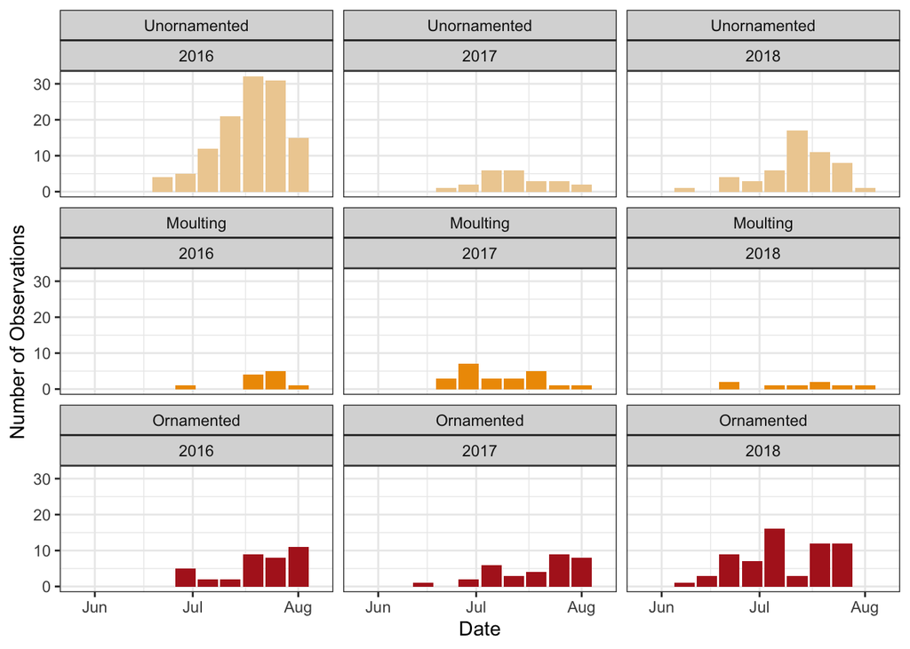

```r
boundary_dates <- c("20160601", "20170601", "20180601",
                    "20160701", "20170701", "20180701",
                    "20160801", "20170801", "20180801")
date_breaks <- tibble(dates = ymd(boundary_dates),
                      year = year(dates),
                      week = week(dates),
                      month = month(dates, label = TRUE)) %>%
  group_by(month) %>%
  summarize(values = mean(week)) %>% pull(values)

figure_s1 <- RBFW %>%
  mutate(Plumage_group = case_when(Plumage_group == "DULL" ~ "Unornamented",
                                   Plumage_group == "MOULT" ~ "Moulting",
                                   Plumage_group == "BRIGHT" ~ "Ornamented"),
         Plumage_group = factor(Plumage_group,
                                levels = c("Unornamented", "Moulting", "Ornamented"))) %>%
  mutate(Year = year(Date),
         Week = week(Date)) %>%
  select(Plumage_group, Year, Week) %>%
  group_by(Plumage_group,Year, Week) %>%
  summarize(n = n()) %>%
  ungroup() %>%
  ggplot(aes(x = Week, y = n, fill = Plumage_group)) +
  geom_col() +
  facet_wrap(Plumage_group ~Year) +
  scale_fill_manual(values = class_colors) +
  theme_bw() +
  theme(legend.position = "none") +
  ylab("Number of Observations") +
  xlab("Date") +
  scale_x_continuous(breaks = date_breaks, labels = c("Jun", "Jul", "Aug"),
                     limits = c(21, 32))

figure_s1
```

## Figure S2

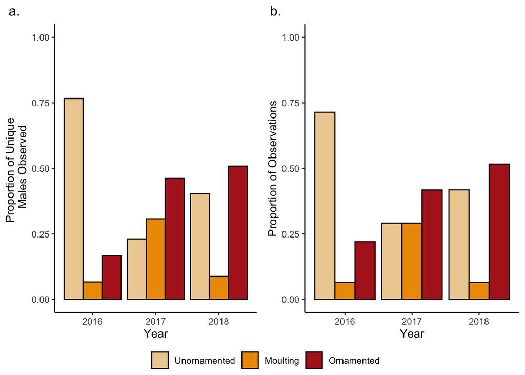

```r
year_unique_males <- RBFW %>%
  mutate(Bird_ID_plumage = paste(Bird_ID, Plumage_group, sep = "")) %>%
  group_by(Year) %>%
  summarize(Sample_size = length(unique(Bird_ID_plumage)))


figure_s2_a <- RBFW %>%
  mutate(Plumage_group = case_when(Plumage_group == "DULL" ~ "Unornamented",
                                   Plumage_group == "MOULT" ~ "Moulting",
                                   Plumage_group == "BRIGHT" ~ "Ornamented"),
         Plumage_group = factor(Plumage_group,
                                levels = c("Unornamented", "Moulting", "Ornamented"))) %>%
  left_join(year_unique_males, by = "Year") %>%
  group_by(Year, Plumage_group, Bird_ID, Sample_size) %>%
  summarize(n = n()) %>%
  ungroup() %>%
  group_by(Year, Plumage_group, Sample_size) %>%
  summarize(n = n()) %>%
  ungroup() %>%
  mutate(Proportion = n/Sample_size) %>%
  ggplot(aes(x = Year, y = Proportion, fill = Plumage_group)) +
  geom_col(position = "dodge", color = "black") +
  scale_fill_manual(values = class_colors, name = "") +
  theme_simple +
  labs(y = "Proportion of Unique \n Males Observed",
       fill = "Plumage group") +
  ggtitle("a.") +
  ylim(0, 1) +
  theme(plot.title = element_text(hjust = -0.24))


year_sample_size <- RBFW %>%
  group_by(Year) %>%
  summarize(Sample_size = n())


figure_s2_b <- RBFW %>%
  mutate(Plumage_group = case_when(Plumage_group == "DULL" ~ "Unornamented",
                                   Plumage_group == "MOULT" ~ "Moulting",
                                   Plumage_group == "BRIGHT" ~ "Ornamented"),
         Plumage_group = factor(Plumage_group,
                                levels = c("Unornamented", "Moulting", "Ornamented"))) %>%
  left_join(year_sample_size, by = "Year") %>%
  group_by(Year, Plumage_group, Sample_size) %>%
  summarize(Year_sum = n()) %>%
  ungroup() %>%
  mutate(Proportion = Year_sum/Sample_size) %>%
  ggplot(aes(x = Year, y = Proportion,
             fill = Plumage_group)) +
  geom_col(position = "dodge", color = "black") +
  theme_simple +
  scale_fill_manual(values = class_colors, name = "") +
  labs(y = "Proportion of Observations", fill = "") +
  ggtitle("b.") +
  ylim(0, 1) +
  theme(plot.title = element_text(hjust = -0.17))


figure_s2 <- ggarrange(figure_s2_a, figure_s2_b, ncol=2, nrow=1,
                       common.legend = TRUE, legend="bottom")
figure_s2
```

##### Bookmark 29 September 2022

I need to clean this code up

#### Bookmark 2 October 2022

I need to add heat map figure code